# Video Game Sales

I have used a data set I found off of Kaggle

VideoGame Sales as of 10/26/2016. Kaggle url - https://www.kaggle.com/gregorut/videogamesales orginal data - http://www.vgchartz.com/gamedb/

I want to empthize that I did NOT look at the Kaggle users findings. I only used the cvs file provided.

It should be noted that Sales are units sold in millions.

My main interest with this data is Sales (regional sales?) by: (Naming these three “tri” in my questions) platform genre publisher

ps1 - December 3, 1994 ps2 - March 4, 2000 ps3 - November 11, 2006

questions which tri has the highest sales? what is the average sale per tri? if a publisher produces “x” genre, what is the expected sale?

limitations of data: Not all games are included in this data (ie: indie games on steam)

```r
vgyear <- as.integer(as.character(vg_data$Year))
```

```
NAs introduced by coercion
```

Plot Matrix

```r
library(GGally)
```

first I wanted to take a glimpse of publishers and sales

Publishers Plots

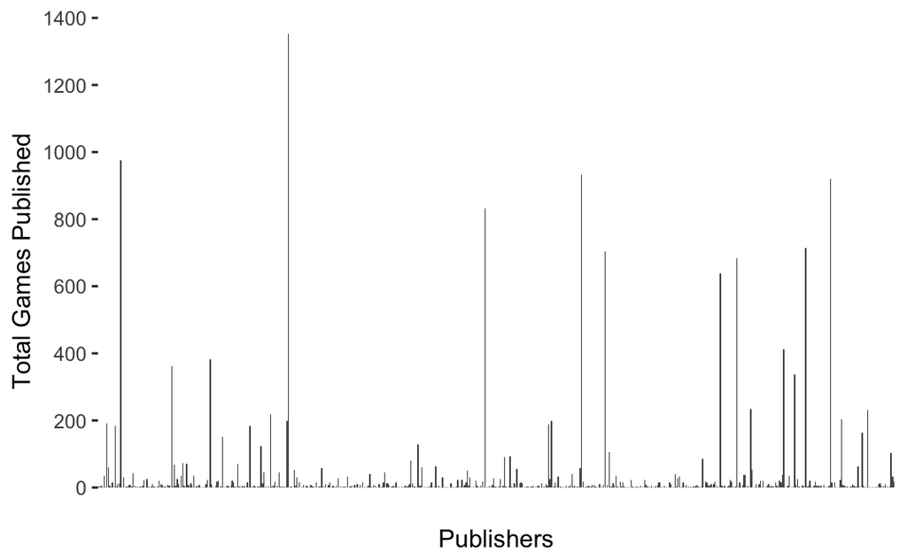

Next, I would like to take a look at sales (in millions) of games.

Sales over the years

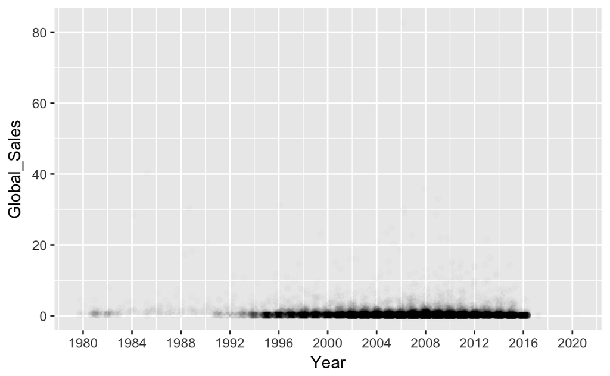

Taking a look at Global Sales, we can see that more sales are made around 1997. Growing up around this time, I speculate the increase of sales is due to better technology. Arcade games started be released around the 80s, and we can see some blotches of sales a few years after. Then it starts to die down after 1984. It does pick up again until the release of Sega Genesis and Super Nintendo consoles in 1989 and 1990. Shortly afterwards sales started to increase again and steadly increase for the years to come. Growing up in the 90’s, I speculate that the increase of sales was due to better technology and newer generations of consoles. With technology always improving, I questioned why sales started to decrease in the late 2000’s.

```r
ggplot(aes(y=sum_sale, x=Year), data = grouped_year) +
  geom_point() +
  geom_line() +
  scale_x_continuous(breaks = seq(0,2017,5))
```

[output not shown]

There could be a number of reasons that can explain the sudden drop in sales. One of reasons could simply be that publishers just did not realse as much games as it did in the past.

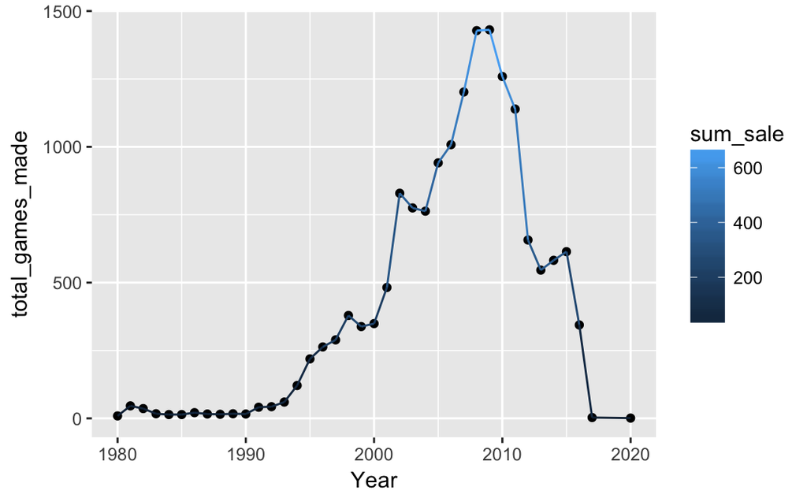

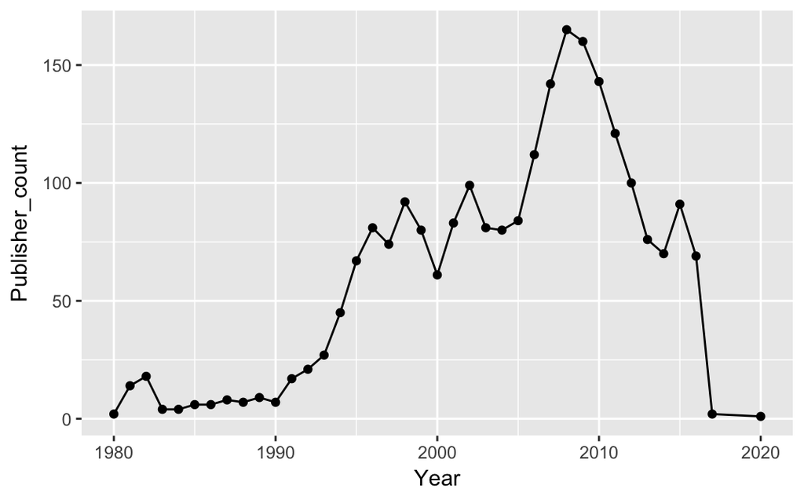

This graph verifies that publishing companies stop producing as many games as it did in the past. At this point, I do not have any data that can explain why pusblishing companies produce less games or even go out of business. I do have some theories thoough.

Looking vg chartz, you can dig deeper and see the type of sale for a particular game. For the most part, games are purchashed through retail stores, which a bulk of my data, retail game sales. The data does not contain all digital sales (ie: Sales made over the internet). With technology become better, there is not a need to buy a compact disk or cartridge. It would be cheaper for publishers to just provide the game digitally.

My theory of the decline in sales is becausegames created andpublished by smaller companies. Or because mobile games (eg: cell phone game apps) became more popular as well.

```r
library(dplyr)
```

Now that I have an indepth understanding of sales, publishers, and games created over the years, its time to ask questions about consoles and their sales

```r
ggplot(data = sales_by_platform.regions, aes(x=Platform, y=sum)) +
  geom_line()
```

[output not shown]

With this information, I wanted to subset the data to focus on the 6 platforms that made over 200 million sales.

```r
top_six <- subset(vg_data, Platform == "Wii" | Platform == 'PS2' | Platform == 'X360' | Platform == 'PS3' | Platform == 'DS' |  Platform == 'PS')
```

[output not shown]

```r
# Sales consoles
ggplot(data = top_six, aes(x = Year, y = Global_Sales)) +
  geom_point(aes(color = Platform), position = position_jitter(h=0), alpha = 1/5) +
  coord_cartesian(xlim = seq(1990,2020,5), ylim = c(0,20)) +
  geom_line(stat = 'summary', fun.y=mean)


ggplot(data = top_six, aes(x = Year, y = Global_Sales)) +
  geom_point(aes(color = Platform), position = position_jitter(h=0), alpha = 1/5) +
  geom_line(stat = 'summary', fun.y=mean) +
  geom_line(stat = 'summary', fun.y = quantile,
            fun.args = list(probs = .9), linetype = 2, color = 'blue') +
   geom_line(stat = 'summary', fun.y = quantile,
            fun.args = list(probs = .1), linetype = 2, color = 'red') +
  coord_trans(y = 'sqrt')+
  ylim(c(0,15))
```

[output not shown]

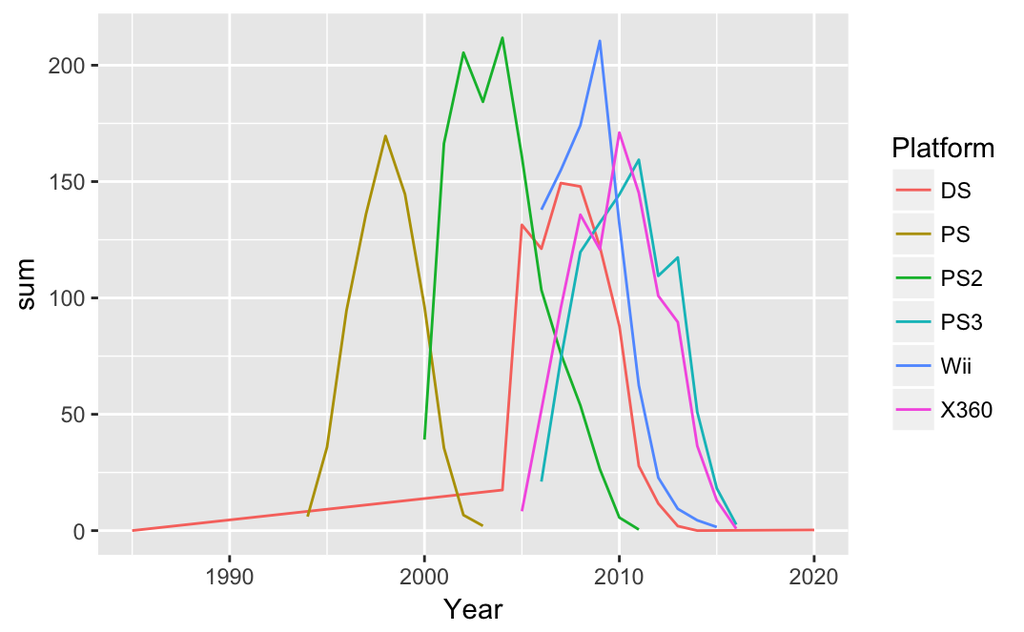

The graph is a little messy but it gets us a better visualization of the life span of a console and when they peaked in sales.

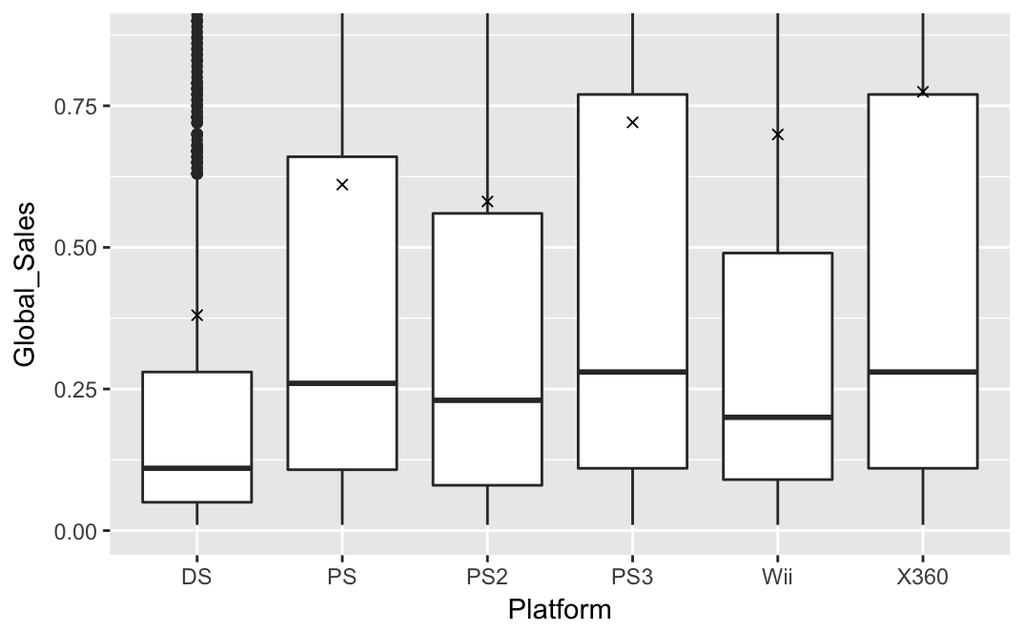

What I found most intreging is the PS3 and X360 having very similar box plots. My previous plots showed that X360 did better then teh ps3, but this box plot shows that they did fairly similar in sales. Considering that these two are “rival” platforms, lets look at it in ratios.

```r
ggplot(data = global_sales.top_six, aes(x = Year, y = sum)) +
  geom_line(aes(color = Platform), data = subset(global_sales.top_six, Platform == 'X360')) +
  geom_line(aes(color = Platform), data = subset(global_sales.top_six, Platform == 'PS3')) +
  coord_cartesian(xlim = seq(2010,2016,1))
```

[output not shown]

Another thing i wanted to look at is which Genre and sales. Personally RPG’s are my faviorate, but how did it compare to shooters when games like Call of Duty became more popular?

```r
#overview of genre and their sales

ggplot(data = subset(vg_data, !is.na(Global_Sales)), aes(x= Year, y=Global_Sales))+
  geom_point(position = position_jitter(h=0), aes(color = Genre))

str(vg_data$Global_Sales)
```

[output not shown]

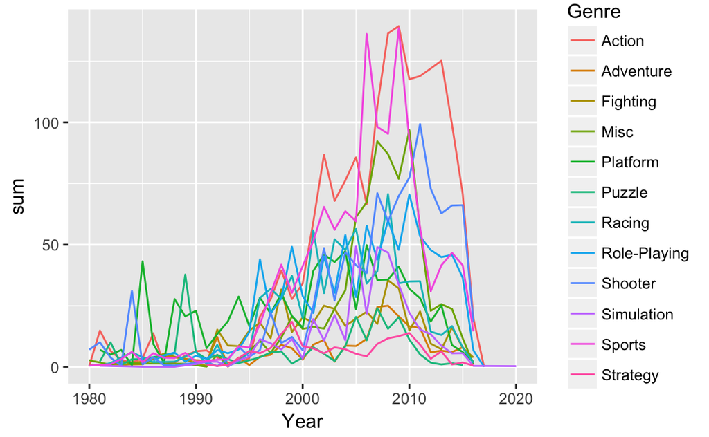

Here it’s a little bit messy, but we can a get overview of genre trends.

Looking at this data also made me question it. For example what is a “Misc” Genre? After taking a look the data, these Misc genre are party games like Mario Party, or Exersicing/Education games. It made me realize that some games by have Multiple genre, ie: Mario Part could be both puzzle and fighting or Guitar Hero could be a Simulation or Puzzle.

It is also intresting to note that some games are easier to develop then others. For example, with a RPG creators would to develope the an entire virtual world from scratch, while a Shooter game you can use a blue pring and create a world around it.

```r
ggplot(data = global_sales.genre, aes(x = Year, y = sum)) +
  geom_line(aes(color = Genre), data = subset(global_sales.genre, Genre == 'Sports')) +
  geom_line(aes(color = Genre), data = subset(global_sales.genre, Genre == 'Role-Playing'))
```

[output not shown]

```r
# region, genre, count

region_sales.genre <- vg_data %>%
  group_by(Year, Genre)  %>%
  summarise( eu_sumSales = sum(EU_Sales),
                         jp_sumSales =  sum(JP_Sales),
                         na_sumSales =  sum(NA_Sales),
                         other_sumSales = sum(Other_Sales)) %>%
  arrange(Year)

region.genre.sales <-  gather(region_sales.genre, 'region', 'sales', -Year, -Genre)

library(dplyr)
detach("package:dplyr", unload=TRUE)
library(tidyr)
detach("package:tidyr", unload=TRUE)

region.genre.sales <- region.genre.sales %>%
  group_by(Year, Genre, region)  %>%
  summarise(sum = sum(sales))%>%
  arrange(Year)

ggplot(data = subset(region.genre.sales, region == "eu_sumSales" & Genre == 'Action'), aes(y = sum, x = Year)) +
  geom_line() +
  geom_line(data= subset(region.genre.sales, region == "jp_sumSales" & Genre == 'Action'), color = 'red') +
  geom_line(data= subset(region.genre.sales, region == "na_sumSales" & Genre == 'Action'), color = 'green') +
  geom_line(data= subset(region.genre.sales, region == "other_sumSales" & Genre =='Action'),color = 'blue')
```

[output not shown]

```r
ggplot(data = subset(region.genre.sales, region == "eu_sumSales" & Genre == 'Sports'), aes(y = sum, x = Year)) +
  geom_line() +
  geom_line(data= subset(region.genre.sales, region == "jp_sumSales" & Genre == 'Sports'), color = 'red') +
  geom_line(data= subset(region.genre.sales, region == "na_sumSales" & Genre == 'Sports'), color = 'green') +
  geom_line(data= subset(region.genre.sales, region == "other_sumSales" & Genre =='Sports'),color = 'blue')
```

[figure not shown]

[figure not shown]

[x] Console VS Sales  
[] Genre VS Sales (need LR) [] Genre VS Reginal (Sales need LR) [] Publisher VS Genre (with Sales ie: which publisher makes best shooter)

We can see that global video games sales did not kick off until after the mid 90’s. During this time, The PS1 and N64 consoles were released. One can speculate that technology drasticly improved as time went on causing an increase in sales.

more indie games being released, more developer (mobile phone games), digital sales etc, could contribute.

Reflection Where you had a hard time - converting years into numeric - geom line = mean, when theres no y axis - grouping vs aggregate - lots of qualitative V quanititiave, would like more quant VS quant - Reshaping my data using gather/melt/dcast was hard

How can the data be improved? First and formost, not have data from 2020 or include presale fix the 271 data with no year Digital Sales VS Retail (not all included?) population of region (better to ratio it out?)